# Problemas de ANOVA (desarrollados)

Bioestadística

Diciembre 2026

En estos problemas **no hace falta calcular un ANOVA desde cero**: el objetivo es saber **leer e interpretar** sus resultados. Todo se resuelve a mano (con calculadora). Recuerda:

- **Estadístico F**: $F = \dfrac{MS_{entre}}{MS_{dentro}}$, con $MS = \dfrac{SS}{gl}$
- **Grados de libertad** (una vía, $g$ grupos y $N$ observaciones): $gl_{entre} = g - 1$, $\;gl_{dentro} = N - g$, $\;gl_{total} = N - 1$
- **Decisión**: si $F_{obs} > F_{crit}(gl_{entre}, gl_{dentro})$ → rechazamos $H_0$ (o, lo que es lo mismo, si p < α)
- **Tamaño del efecto**: $R^2 = \eta^2 = \dfrac{SS_{entre}}{SS_{total}}$ (orientativo: 0.01 pequeño, 0.06 mediano, 0.14 grande)
- Los **supuestos** (normalidad y homogeneidad de varianzas) se comprueban sobre los **residuos**. Si no se cumplen: transformar, Welch-ANOVA o Kruskal-Wallis
- Si el ANOVA es significativo → **test *post hoc*** (Tukey; Games-Howell tras Welch; Dunn tras Kruskal-Wallis)

**Tabla de valores críticos de F** (cola superior, α = 0.05):

|  | $gl_1$ = 1 | $gl_1$ = 2 | $gl_1$ = 3 | $gl_1$ = 4 | $gl_1$ = 5 | $gl_1$ = 6 |
| --- | --- | --- | --- | --- | --- | --- |
| **$gl_2$ = 15** | 4.54 | 3.68 | 3.29 | 3.06 | 2.90 | 2.79 |
| **$gl_2$ = 19** | 4.38 | 3.52 | 3.13 | 2.90 | 2.74 | 2.63 |
| **$gl_2$ = 20** | 4.35 | 3.49 | 3.10 | 2.87 | 2.71 | 2.60 |
| **$gl_2$ = 27** | 4.21 | 3.35 | 2.96 | 2.73 | 2.57 | 2.46 |
| **$gl_2$ = 30** | 4.17 | 3.32 | 2.92 | 2.69 | 2.53 | 2.42 |
| **$gl_2$ = 40** | 4.08 | 3.23 | 2.84 | 2.61 | 2.45 | 2.34 |
| **$gl_2$ = 54** | 4.02 | 3.17 | 2.78 | 2.54 | 2.39 | 2.27 |
| **$gl_2$ = 60** | 4.00 | 3.15 | 2.76 | 2.53 | 2.37 | 2.25 |
| **$gl_2$ = 65** | 3.99 | 3.14 | 2.75 | 2.51 | 2.36 | 2.24 |
| **$gl_2$ = 66** | 3.99 | 3.14 | 2.74 | 2.51 | 2.35 | 2.24 |

$gl_1$: grados de libertad del numerador (entre grupos); $gl_2$: grados de libertad del denominador (dentro de los grupos).

## 💡 Problema 1 - Luz detrás de las rodillas

En 1998 se publicó en *Science* que iluminar la **parte de atrás de las rodillas** podía desplazar el reloj circadiano, igual que la luz que entra por los ojos. En 2002, Wright y Czeisler repitieron el experimento con más control. Asignaron al azar **22 personas** a tres grupos: sin luz (**Control**), luz en las **Rodillas** y luz en los **Ojos**. Midieron el desplazamiento del ritmo circadiano (en horas; un valor negativo indica un retraso del reloj) a partir de los niveles de melatonina:

|  | Control | Rodillas | Ojos |
| --- | --- | --- | --- |
| *n* | 8 | 7 | 7 |
| Media (h) | −0.31 | −0.34 | −1.55 |
| Desviación típica (h) | 0.62 | 0.79 | 0.71 |

La tabla del ANOVA ha quedado incompleta:

| Fuente de variación | gl | SS | MS | F |
| --- | --- | --- | --- | --- |
| Grupo (entre grupos) | ? | 7.224 | ? | ? |
| Residuos (dentro de los grupos) | ? | 9.415 | ? |  |
| Total | ? | 16.639 |  |  |

### a) Escribe las hipótesis nula y alternativa del ANOVA.

### b) Completa la tabla: grados de libertad, medias cuadráticas (MS) y F.

### c) Busca la F crítica (α = 0.05). ¿Rechazas $H_0$? ¿Qué puedes concluir (y qué **no** puedes concluir todavía)?

### d) Calcula el $R^2 = \eta^2$ e interprétalo. ¿Es un efecto pequeño, mediano o grande?

### e) Los supuestos se cumplen (Shapiro-Wilk sobre los residuos: p = 0.47; Levene: p = 0.85). Estos son los resultados del test de Tukey. ¿Qué grupos son diferentes? ¿Funciona la luz en las rodillas?

| Comparación | Diferencia de medias (h) | IC 95% | p ajustado |
| --- | --- | --- | --- |
| Rodillas − Control | −0.03 | [−0.95, 0.90] | 0.997 |
| Ojos − Control | −1.24 | [−2.17, −0.32] | 0.008 |
| Ojos − Rodillas | −1.22 | [−2.17, −0.26] | 0.012 |

**Solución desarrollada**

**a) Hipótesis**

- $H_0$: $\mu_{Control} = \mu_{Rodillas} = \mu_{Ojos}$ (el tipo de luz no afecta al desplazamiento del reloj)
- $H_A$: al menos una de las medias es diferente

**b) Tabla completa**

Hay $g = 3$ grupos y $N = 8 + 7 + 7 = 22$ personas:

- $gl_{entre} = g - 1 = 2$; $\;gl_{dentro} = N - g = 22 - 3 = 19$; $\;gl_{total} = N - 1 = 21$ (comprobación: 2 + 19 = 21)
- $MS_{entre} = \dfrac{7.224}{2} = 3.612$; $\;MS_{dentro} = \dfrac{9.415}{19} = 0.496$
- $F = \dfrac{3.612}{0.496} = 7.29$

| Fuente de variación | gl | SS | MS | F |
| --- | --- | --- | --- | --- |
| Grupo (entre grupos) | 2 | 7.224 | 3.612 | 7.29 |
| Residuos (dentro de los grupos) | 19 | 9.415 | 0.496 |  |
| Total | 21 | 16.639 |  |  |

**c) Decisión**

En la tabla, $F_{crit}(2, 19) = 3.52$. Como $F_{obs} = 7.29 > 3.52$, **rechazamos $H_0$** (el p-valor exacto es 0.004).

Podemos concluir que **al menos uno** de los tres grupos tiene una media diferente. Lo que **no** podemos concluir todavía es **cuál** (o cuáles): para eso necesitamos un test *post hoc*.

**d) Tamaño del efecto**

$$R^2 = \eta^2 =
\frac{SS_{entre}}{SS_{total}} = \frac{7.224}{16.639} = 0.43$$

El tipo de luz explica el **43%** de la variabilidad del desplazamiento del reloj circadiano. Es un **efecto grande** (muy por encima de 0.14).

**e) Test de Tukey**

Miramos la columna del p-valor ajustado por comparaciones múltiples:

- Rodillas − Control: diferencia de −0.03 h, p = 0.997 → **no hay diferencias**
- Ojos − Control: diferencia de −1.24 h, p = 0.008 → **diferentes**
- Ojos − Rodillas: diferencia de −1.22 h, p = 0.012 → **diferentes**

Lo mismo se ve con los intervalos de confianza: el de Rodillas − Control incluye el 0, mientras que los de las comparaciones con Ojos no.

La luz en los ojos retrasa el reloj circadiano unas 1.2 horas, pero **la luz en las rodillas no tiene ningún efecto**: su media es prácticamente igual a la del control. El ANOVA era significativo solo por el grupo de los Ojos. Wright y Czeisler concluyeron que el resultado de 1998 no se podía reproducir.

## 🐛 Problema 2 - ¿Qué insecticida funciona mejor?

En un experimento agrícola clásico (Beall, 1942) se comparó la eficacia de **6 insecticidas** (A a F). Cada uno se aplicó en **12 parcelas** y se contó el número de insectos que quedaban en cada parcela:

| Insecticida | A | B | C | D | E | F |
| --- | --- | --- | --- | --- | --- | --- |
| Media | 14.50 | 15.33 | 2.08 | 4.92 | 3.50 | 16.67 |
| Desviación típica | 4.72 | 4.27 | 1.98 | 2.50 | 1.73 | 6.21 |

Se hizo un ANOVA de una vía:

| Fuente de variación | gl | SS | MS | F |
| --- | --- | --- | --- | --- |
| Insecticida (entre grupos) | 5 | 2668.8 | 533.8 | 34.70 |
| Residuos (dentro de los grupos) | 66 | 1015.2 | 15.4 |  |

Y se comprobaron los supuestos sobre los residuos:

- Test de Shapiro-Wilk: W = 0.96, **p = 0.022**
- Test de Levene: F = 3.82, **p = 0.004**

### a) Con la F crítica, el ANOVA sería claramente significativo. Pero antes de concluir nada: ¿se cumplen los supuestos del ANOVA? ¿Puedes fiarte de este resultado?

### b) Fíjate en las medias y las desviaciones típicas de la tabla. ¿Ves algún patrón que explique por qué falla la homogeneidad de varianzas? (Pista: son **recuentos**; piensa en la distribución de Poisson.)

### c) ¿Qué test usarías como alternativa? Su resultado es **χ² = 54.69, gl = 5, p < 0.001**. Interprétalo.

### d) Estos son los resultados del *post hoc* adecuado (p-valores ajustados por Holm). ¿Qué insecticidas recomendarías? ¿Hay diferencias entre los tres mejores?

| Comparación | p ajustado |  | Comparación | p ajustado |  | Comparación | p ajustado |
| --- | --- | --- | --- | --- | --- | --- | --- |
| A − B | 1 |  | B − C | < 0.001 |  | C − E | 1 |
| A − C | < 0.001 |  | B − D | 0.005 |  | C − F | < 0.001 |
| A − D | 0.013 |  | B − E | < 0.001 |  | D − E | 1 |
| A − E | 0.001 |  | B − F | 1 |  | D − F | 0.004 |
| A − F | 1 |  | C − D | 0.586 |  | E − F | < 0.001 |

### e) Un compañero propone olvidarse del ANOVA y hacer t-tests comparando los insecticidas dos a dos. ¿Cuántos tests tendría que hacer? ¿Cuál sería la probabilidad de obtener al menos un falso positivo (α = 0.05)?

**Solución desarrollada**

**a) Supuestos**

Con $F_{crit}(5, 66) = 2.35$, la F observada (34.70) sería claramente significativa. Pero:

- **Normalidad de los residuos**: Shapiro-Wilk p = 0.022 < 0.05 → rechazamos que los residuos sean normales.
- **Homogeneidad de varianzas**: Levene p = 0.004 < 0.05 → rechazamos que las varianzas sean iguales.

**No se cumple ninguno de los dos supuestos**, así que no podemos fiarnos del resultado del ANOVA, por grande que sea la F. Primero hay que elegir un test adecuado.

**b) El patrón de las varianzas**

Los insecticidas con medias altas (A, B, F: 14.5–16.7 insectos) tienen desviaciones típicas grandes (4.3–6.2), y los de medias bajas (C, D, E: 2.1–4.9) tienen desviaciones típicas pequeñas (1.7–2.5). La **varianza aumenta con la media**.

Es lo esperable en datos de **recuento**: si siguen una distribución de **Poisson**, la varianza es igual a la media ($\sigma^2 = \lambda$). Por eso, en datos de recuento es muy habitual que falle la homogeneidad de varianzas. (Una transformación como $\sqrt{y}$ suele arreglarlo, pero aquí usaremos la alternativa no paramétrica.)

**c) Kruskal-Wallis**

Como no se cumple la normalidad (ni la homogeneidad), usamos la alternativa no paramétrica: el **test de Kruskal-Wallis**.

- $H_0$: el número de insectos tiene la misma distribución con todos los insecticidas
- $H_A$: al menos un insecticida es diferente

p < 0.001 < 0.05 → **rechazamos $H_0$**: al menos un insecticida deja un número de insectos diferente.

Si quisiéramos el tamaño del efecto, se puede calcular a mano a partir del estadístico H (el χ²), con $k$ grupos y $n$ observaciones:

$$\eta^2_H = \frac{H - k + 1}{n - k} =
\frac{54.69 - 6 + 1}{72 - 6} = 0.75$$

Un efecto grande.

**d) *Post hoc* de Dunn**

Tras un Kruskal-Wallis significativo, el *post hoc* adecuado es el **test de Dunn**, con corrección de p-valores (aquí, Holm):

- **C, D y E** frente a **A, B y F**: todas las comparaciones son significativas (p < 0.05)
- **Entre C, D y E**: ninguna diferencia significativa (C–D p = 0.59; C–E y D–E p = 1)
- **Entre A, B y F**: ninguna diferencia significativa (p = 1)

Los insecticidas se separan en **dos grupos**: C, D y E son eficaces (dejan entre 2 y 5 insectos de media) y A, B y F mucho menos (14–17 insectos). Recomendaríamos **C, D o E**. Aunque C tiene la media más baja, con estos datos **no podemos decir que sea mejor que D o E**.

**e) Comparaciones múltiples**

Con 6 insecticidas hay $\dfrac{6 \times 5}{2} = 15$ comparaciones por pares. Si cada test tiene un 5% de probabilidad de falso positivo:

$$P(\text{al menos un falso positivo}) = 1
- 0.95^{15} = 1 - 0.46 = 0.54$$

Habría un **54%** de probabilidad de encontrar alguna diferencia “significativa” que no es real. Por eso primero se hace un test global (ANOVA o Kruskal-Wallis) y después un *post hoc* que corrige por comparaciones múltiples.

## 🦷 Problema 3 - Vitamina C y dientes de cobaya

Las cobayas, como nosotros, no pueden sintetizar vitamina C. Crampton (1947) estudió cómo afecta la vitamina C al crecimiento de los **odontoblastos** (las células que forman la dentina de los dientes). Usó **60 cobayas**, repartidas en 6 grupos de 10, combinando dos factores:

- **Suplemento**: zumo de naranja (**OJ**) o ácido ascórbico puro (**VC**)
- **Dosis**: 0.5, 1 o 2 mg de vitamina C al día

Longitud media de los odontoblastos en cada grupo:

| Suplemento | 0.5 mg | 1 mg | 2 mg |
| --- | --- | --- | --- |
| Zumo de naranja (OJ) | 13.2 | 22.7 | 26.1 |
| Ácido ascórbico (VC) | 8.0 | 16.8 | 26.1 |

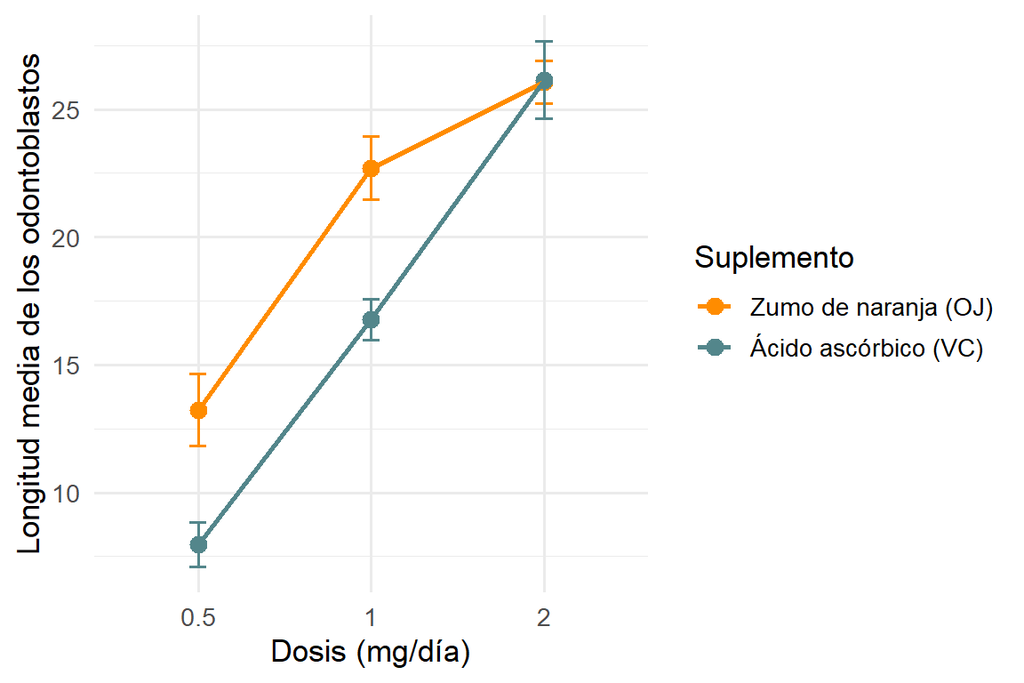

Se hizo un ANOVA de dos vías con interacción:

| Fuente de variación | gl | SS | MS | F |
| --- | --- | --- | --- | --- |
| Suplemento | 1 | 205.4 | 205.4 | 15.57 |
| Dosis | 2 | 2426.4 | 1213.2 | 92.00 |
| Suplemento × Dosis | 2 | 108.3 | 54.2 | 4.11 |
| Residuos | 54 | 712.1 | 13.2 |  |

Los supuestos se cumplen (Shapiro-Wilk sobre los residuos: p = 0.67; Levene: p = 0.15).

### a) ¿Cuántas hipótesis nulas se ponen a prueba en este ANOVA de dos vías? Escríbelas.

### b) Busca la F crítica (α = 0.05) para cada una de ellas y decide si rechazas $H_0$.

### c) Usa el gráfico (o la tabla de medias) para explicar qué significa la interacción Suplemento × Dosis.

### d) Una noticia dice: “El zumo de naranja es mejor que la vitamina C pura para los dientes”. ¿Es correcto con estos datos?

### e) Calcula el $R^2$ del modelo. ¿Qué proporción de la variabilidad explican los dos factores y su interacción?

**Solución desarrollada**

**a) Hipótesis**

En un ANOVA de dos vías con interacción se ponen a prueba **tres** hipótesis nulas:

1. **Suplemento**: $H_0$: la longitud media es la misma con OJ que con VC
2. **Dosis**: $H_0$: la longitud media es la misma con las tres dosis
3. **Interacción**: $H_0$: el efecto del suplemento es el mismo en todas las dosis (no hay interacción)

**b) Decisión**

Los grados de libertad del denominador son los de los residuos: $gl_2 = 54$ (60 cobayas − 6 grupos).

| Efecto | $gl_1$ | $F_{obs}$ | $F_{crit}(gl_1, 54)$ | Decisión |
| --- | --- | --- | --- | --- |
| Suplemento | 1 | 15.57 | 4.02 | Rechazamos $H_0$ |
| Dosis | 2 | 92.00 | 3.17 | Rechazamos $H_0$ |
| Interacción | 2 | 4.11 | 3.17 | Rechazamos $H_0$ |

Los tres efectos son significativos (los p-valores exactos son 0.0002, < 0.0001 y 0.022).

**c) La interacción**

En el gráfico, las líneas **no son paralelas**:

- A **0.5 y 1 mg**, el zumo de naranja (OJ) da odontoblastos claramente más largos que el ácido ascórbico (VC): unas 5–6 unidades más (13.2 frente a 8.0; 22.7 frente a 16.8).
- A **2 mg**, los dos suplementos dan lo mismo (26.1 frente a 26.1).

Es decir, **el efecto del suplemento depende de la dosis**. Eso es exactamente lo que significa una interacción significativa.

**d) La noticia**

**No es correcta tal como está escrita.** El efecto principal del suplemento es significativo, pero como también lo es la **interacción**, no podemos hablar del efecto del suplemento “en general”: el zumo de naranja solo es mejor a **dosis bajas** (0.5 y 1 mg). A la dosis más alta, da igual qué suplemento se use.

Cuando la interacción es significativa, hay que interpretar el efecto de un factor **dentro de cada nivel del otro**.

**e) $R^2$ del modelo**

$$SS_{total} = 205.4 + 2426.4 + 108.3 +
712.1 = 3452.2$$

$$R^2 = \frac{SS_{supl} + SS_{dosis} +
SS_{supl \times dosis}}{SS_{total}} = \frac{2740.1}{3452.2} =
0.79$$

Los dos factores y su interacción explican el **79%** de la variabilidad en la longitud de los odontoblastos. Casi todo se debe a la **dosis** ($SS = 2426.4$, el 70% de la variabilidad total). Si quisiéramos el tamaño del efecto de cada factor por separado, usaríamos el $\eta^2$ parcial: por ejemplo, para la dosis, $\eta^2_p = \dfrac{2426.4}{2426.4 + 712.1} = 0.77$.

## 🐣 Problema 4 - Completa la tabla

En un estudio se criaron pollitos con **diferentes dietas** y, a las seis semanas, se pesaron (en gramos). Al copiar la tabla del ANOVA se han perdido algunos valores:

| Fuente de variación | gl | SS | MS | F |
| --- | --- | --- | --- | --- |
| Dieta (entre grupos) | 5 | 231 129 | ? | ? |
| Residuos (dentro de los grupos) | 65 | ? | 3 009 |  |
| Total | ? | 426 685 |  |  |

### a) ¿Cuántas dietas se compararon? ¿Cuántos pollitos había en total?

### c) Busca la F crítica (α = 0.05). ¿Afecta la dieta al peso de los pollitos?

### d) Calcula el $R^2$ e interprétalo.

**Solución desarrollada**

**a) Número de dietas y de pollitos**

- $gl_{entre} = g - 1 = 5$ → $g = 6$ **dietas**
- $gl_{total} = gl_{entre} + gl_{dentro} = 5 + 65 = 70 = N - 1$ → $N = 71$ **pollitos**

- $SS_{dentro} = SS_{total} - SS_{entre} = 426\,685 - 231\,129 = 195\,556$ (comprobación: $195\,556 / 65 = 3\,009$ ✔)
- $MS_{entre} = \dfrac{231\,129}{5} = 46\,226$
- $F = \dfrac{46\,226}{3\,009} = 15.36$

| Fuente de variación | gl | SS | MS | F |
| --- | --- | --- | --- | --- |
| Dieta (entre grupos) | 5 | 231 129 | 46 226 | 15.36 |
| Residuos (dentro de los grupos) | 65 | 195 556 | 3 009 |  |
| Total | 70 | 426 685 |  |  |

**c) Decisión**

$F_{crit}(5, 65) = 2.36$. Como $F_{obs} = 15.36 > 2.36$, **rechazamos $H_0$**: el peso medio no es el mismo con todas las dietas. Para saber qué dietas son diferentes, haríamos un test *post hoc*.

**d) Tamaño del efecto**

$$R^2 = \frac{231\,129}{426\,685} =
0.54$$

La dieta explica el **54%** de la variabilidad del peso de los pollitos: un efecto muy grande.

## 🤔 Problema 5 - Preguntas rápidas

### a) Un ANOVA da F = 0.8. Sin mirar ninguna tabla, ¿puedes decidir si es significativo?

### b) Un ANOVA con 4 grupos da p = 0.03. ¿Podemos decir que las 4 medias son diferentes entre sí?

### c) Repetimos un experimento con el **doble de individuos** por grupo, y obtenemos las mismas medias y desviaciones típicas. ¿Qué pasa con la F y con el p-valor? ¿Y con el $R^2$?

### d) Los datos cumplen todos los supuestos del ANOVA, pero un compañero prefiere usar Kruskal-Wallis “porque no tiene supuestos”. ¿Es buena idea?

### e) En un ANOVA de una vía se comparan 3 cepas de levadura con 10 réplicas cada una. ¿Cuáles son los grados de libertad del numerador y del denominador? ¿Cuál es la F crítica?

**Solución desarrollada**

**a)** **Sí: no es significativo.** Con α = 0.05, la F crítica es siempre mayor que 1 (mira la tabla: el valor más pequeño es 2.24). Una F < 1 significa que la variabilidad **entre** grupos es incluso menor que la variabilidad **dentro** de los grupos: no hay ninguna evidencia de diferencias.

**b)** **No.** El ANOVA solo nos dice que **al menos una** de las medias es diferente de las demás. Puede que solo un grupo sea distinto y los otros tres sean iguales (como en el Problema 1). Para saber qué grupos difieren hace falta un test *post hoc* (Tukey).

**c)** La $MS_{entre}$ depende del tamaño de los grupos: $SS_{entre} = \sum n_i (M_i - G)^2$. Si duplicamos *n* con las mismas medias, la $MS_{entre}$ se duplica, mientras que la $MS_{dentro}$ (la varianza dentro de los grupos) no cambia. Por tanto, **la F aumenta** (aproximadamente se duplica) y **el p-valor disminuye**: con más datos tenemos más potencia. En cambio, el **$R^2$ se mantiene aproximadamente igual**: el tamaño del efecto no depende del tamaño de la muestra. Es la misma idea que vimos con la *d* de Cohen.

**d)** **No es buena idea.** Si los supuestos se cumplen, el ANOVA tiene **más potencia** que Kruskal-Wallis: es más fácil que detecte una diferencia real (lo vimos con los datos de las aves en clase). Además, Kruskal-Wallis también tiene supuestos: las observaciones deben ser independientes y, para interpretarlo como una comparación de medianas, las distribuciones de los grupos deben tener una forma parecida.

**e)** $g = 3$ cepas y $N = 3 \times 10 = 30$ observaciones:

- $gl_1 = gl_{entre} = 3 - 1 = 2$
- $gl_2 = gl_{dentro} = 30 - 3 = 27$

En la tabla, $F_{crit}(2, 27) = 3.35$. Si la F del experimento es mayor que 3.35, rechazaremos que las tres cepas tengan la misma media.

## 📚 Fuentes

- Wright, K. P. y Czeisler, C. A. (2002). Absence of circadian phase resetting in response to bright light behind the knees. *Science*, 297, 571. Datos en Whitlock, M. C. y Schluter, D. *The Analysis of Biological Data* (ejemplo 15.1).
- Beall, G. (1942). The transformation of data from entomological field experiments, so that the analysis of variance becomes applicable. *Biometrika*, 32, 243–262. Disponibles en R: `InsectSprays`.
- Crampton, E. W. (1947). The growth of the odontoblast of the incisor teeth as a criterion of vitamin C intake of the guinea pig. *The Journal of Nutrition*, 33, 491–504. Disponibles en R: `ToothGrowth`.
- Anónimo (1948). *Biometrika*, 35, 214. Disponibles en R: `chickwts`.